# Propensity Score Analysis with R

December 11, 2019

## Agenda

- Overview of causal inference
  - Counterfactuals
  - Randomized control trials
  - Rubin’s Causal Model
- Propensity Score Analysis in two Phases
  - Various types of treatment effects
  - Matching
  - Stratification
  - Weighting
  - Evaluating Balance
- Sensitivity Analysis
- Matching for Non-Binary Treatments
- Multilevel PSA

## Popularity of Propensity Score Analysis

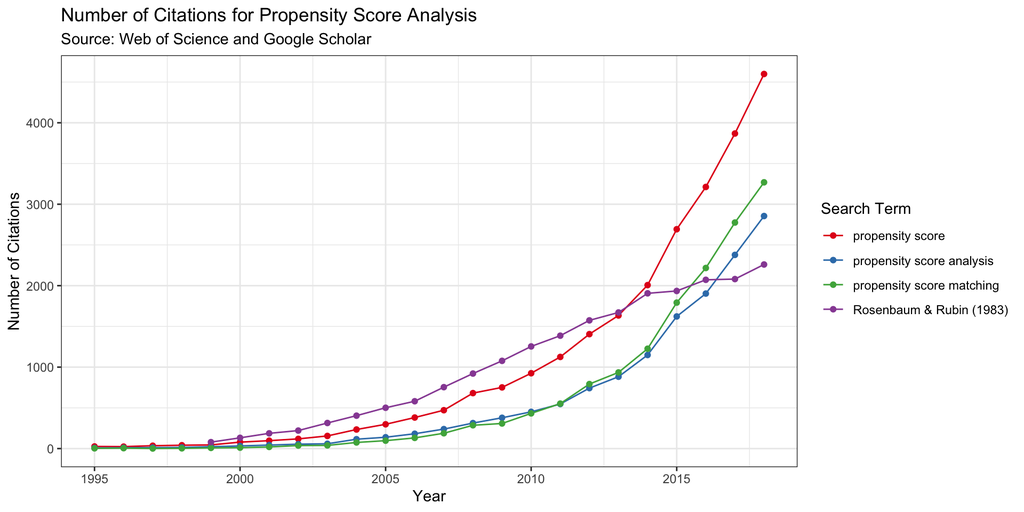

## Counterfactuals

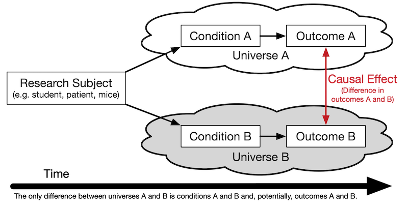

## The Randomized Experiment

Considered to be the *gold standard* for estimating causal effects.

- Effects can be estimated using simple means between groups, or blocks in randomized block design.
- Randomization presumes unbiasedness and balance between groups.

However, randomization is often not feasible for many reasons, especially in educational contexts.

The strong ignorability assumption states that:

\[({ Y }_{ i }(1),{ Y }_{ i }(0)) \; \unicode{x2AEB} \; { T }_{ i }|{ X }_{ i }=x\]

for all \({X}_{i}\).

## RCT Example

```r
set.seed(2112)
pop.mean <- 100
pop.sd <- 15
pop.es <- .3
n <- 30
thedata <- data.frame(
    id = 1:30,
    center = rnorm(n, mean = pop.mean, sd = pop.sd),
    stringsAsFactors = FALSE
)
val <- pop.sd * pop.es / 2
thedata$placebo <- thedata$center - val
thedata$treatment <- thedata$center + val
thedata$diff <- thedata$treatment - thedata$placebo
thedata$RCT_Assignment <- sample(c('placebo', 'treatment'), n, replace = TRUE)
thedata$RCT_Value <- as.numeric(apply(thedata, 1,
                    FUN = function(x) { return(x[x['RCT_Assignment']]) }))
head(thedata, n = 3)
```

```
##   id center placebo treatment diff RCT_Assignment RCT_Value
## 1  1    114     112       116  4.5      treatment       116
## 2  2     95      93        98  4.5      treatment        98
## 3  3     91      88        93  4.5      treatment        93
```

```r
tab.out <- describeBy(thedata$RCT_Value, group = thedata$RCT_Assignment, mat = TRUE, skew = FALSE)
```

## True Counterfactual

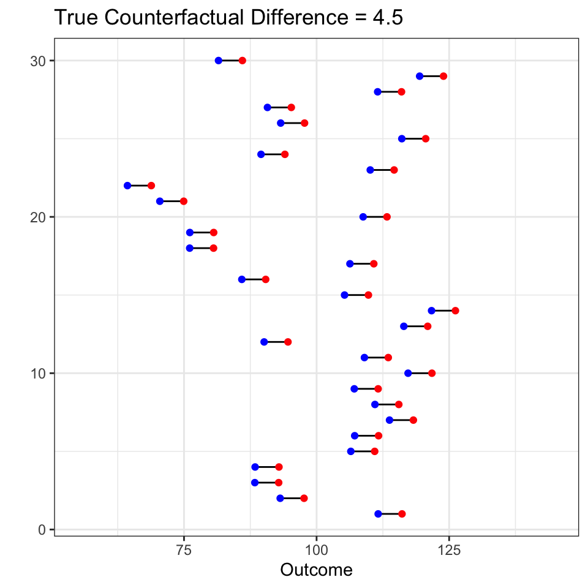

## True Counterfactual (left) vs. One RCT (right)

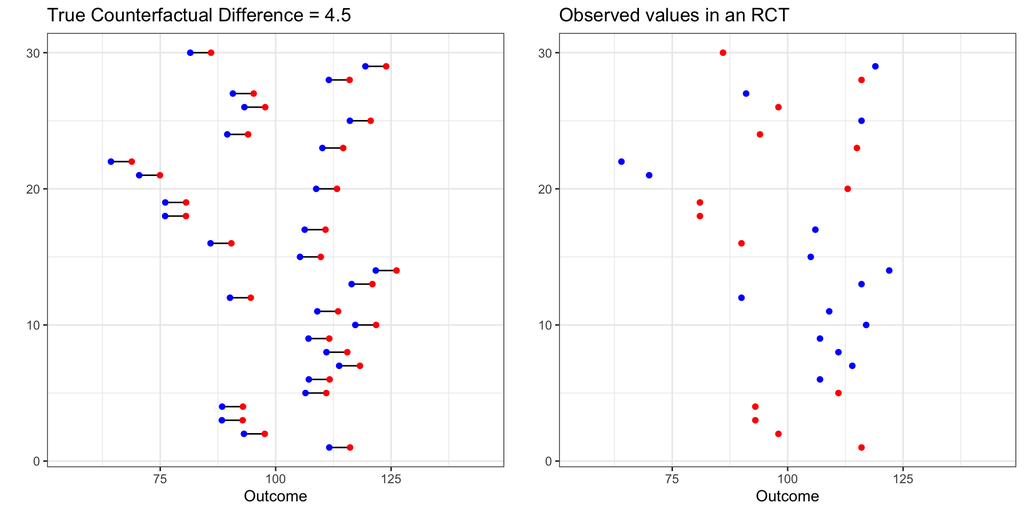

## True Counterfactual (left) vs. One RCT (right)

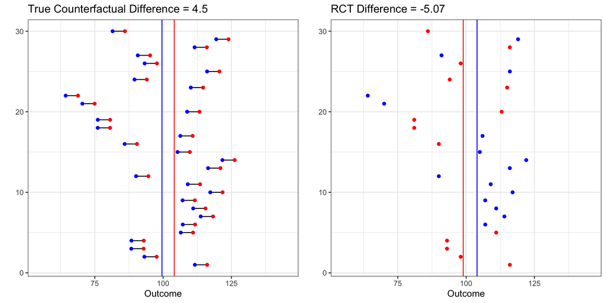

## Distribution of Differences from 1,000 RCTs

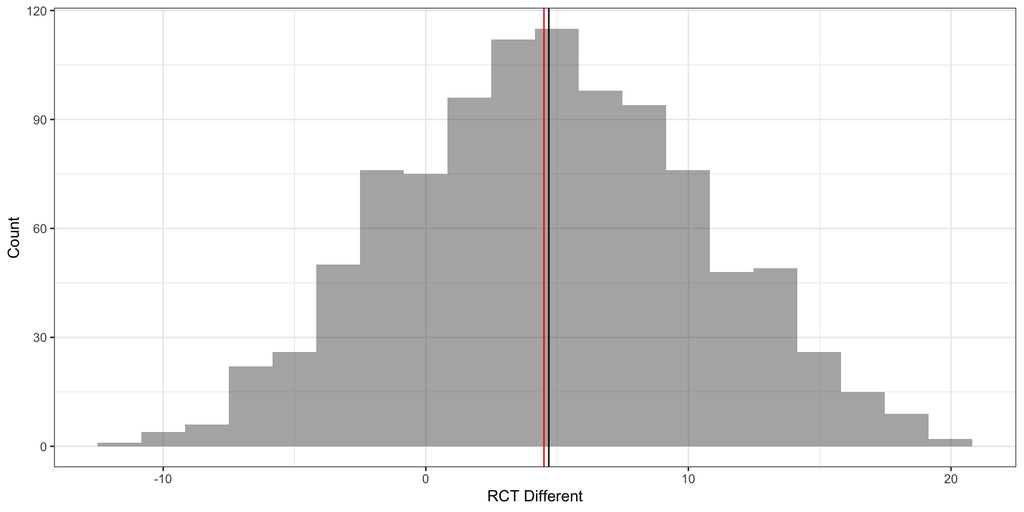

## Rubin Causal ModelSee Rubin, 1974, 1977, 1978, 1980, and Holland, 1986

- The causal effect of a treatment is the difference in an individual’s outcome under the situation they were given the treatment and not (referred to as a counterfactual).

\[{\delta}_{i} ={ Y }_{ i1 }-{ Y }_{ i0 }\]

- However, it is impossible to directly observe \({\delta}_{i}\) (referred to as *The Fundamental Problem of Causal Inference*, Holland 1986).
- Rubin frames this problem as a “missing data problem.”

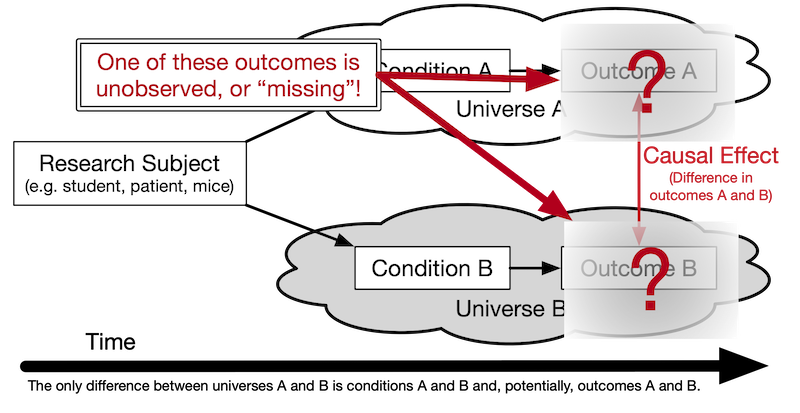

## Propensity Score Analysis

The propensity score is the “conditional probability of assignment to a particular treatment given a vector of observed covariates” (Rosenbaum & Rubin, 1983, p. 41). The probability of being in the treatment: \[\pi ({ X }_{ i }) \; \equiv \; Pr({ T }_{ i }=1|{ X }_{ i })\]

The balancing property under exogeneity:

\[{ T }_{ i } \; \unicode{x2AEB} { X }_{ i } \;| \; \pi ({ X }_{ i })\]

We can then restate the ignorability assumption with the propensity score:

\[({ Y }_{ i }(1),{ Y }_{ i }(0)) \; \unicode{x2AEB} \; { T }_{ i } \; | \; \pi({ X }_{ i })\]

## Treatment Effects

The average treatment effect (ATE) is defined as:

\[E({ r }_{ 1 })-E({ r }_{ 0 })\]

where \(E(.)\) is the expectation in the population. For a set of covariates, \(X\), and outcomes \(Y\) where 0 denotes control and 1 treatment, we define ATE as:

\[ATE=E(Y_{1}-Y_{0}|X)=E(Y_{1}|X)-E(Y_{0}|X)\]

The Average treatment effect on the treated (ATT), is defined as:

\[ATT=E(Y_{1}-Y_{0}|X,C=1)=E(Y_{1}|X,C=1)-E(Y_{0}|X,C=1)\]

## Propensity score methods

- **Matching** - Each treatment unit is paired with a comparison unit based upon the pre-treatment covariates.
- **Stratification** Treatment and comparison units are divided into strata (or subclasses) so that treated and comparison units are similar within each strata. Cochran (1968) observed that creating five subclassifications (stratum) removes at least 90% of the bias in the estimated treatment effect.
- **Weighting** Each observation is weighted by the inverse of the probability of being in that group.

\[\frac { 1 }{ n } \sum _{ i=1 }^{ n }{ \left( \frac { { T }_{ i }{ Y }_{ i } }{ \pi ({ X }_{ i }) } -\frac { (1-{ T }_{ i }){ Y }_{ i } }{ 1-\pi ({ X }_{ i }) } \right) } \]

## Steps for Implementing Matching Methods

Stuart and Rubin (2008) outline the following steps for matching, but the same approach can be used for stratification and weighting as well.

1. Choose the covariates to be used.
2. Define a distance measure (i.e. what constitutes similar).
3. Choose the matching algorithm.
4. Diagnose the matches (or strata) obtained (iterating through steps 2 and 3 as well).
5. Estimate the treatment effect using the matches (or strata) found in step 4.

## Matching Methods

There are many choices and approaches to matching, including:

- Propensity score matching.
- Limited exact matching.
- Full matching.
- Nearest neighbor matching.
- Optimal/Genetic matching.
- Mahalanobis distance matching (for quantitative covariates only).
- Matching with and without replacement.
- One-to-one or one-to-many matching.

**Which matching method should you use?**

*Whichever one gives the best balance!*

See Rosenbaum (2012), *Testing one hypothesis twice in observational studies*.